# R Notebook

Analysis: Identify Sox2::Oct4 Dimer peaks and track their accessibility and H3k27Ac over time.

# A new bit

So Debbie raised a great point. We expect to see this maintained in iNC at D5 because they have not differentiated yet. So we will compare the signal in this vs the differentiated Sox2 C+R she performed. As a reference we have a 14D Myo Sample in which Sox2 C+R and ATAC-Seq have been performed. Also have H3K27Ac I think.

```r
D5_Sox2_Peaks <- reduce(c(Sox2_NC_D5_R1, Sox2_NC_D5_R2))
```

```
Each of the 2 combined objects has sequence levels not in the other:
  - in 'x': chr1_KI270708v1_random, chr9_KI270719v1_random, chrUn_KI270381v1, chrUn_KI270423v1, chrUn_KI270516v1, chrUn_KI270580v1
  - in 'y': chr14_GL000009v2_random, chr14_KI270722v1_random, chr1_KI270710v1_random, chr2_KI270715v1_random, chr9_KI270720v1_random, chrUn_KI270305v1, chrUn_KI270468v1, chrUn_KI270511v1, chrUn_KI270515v1, chrUn_KI270584v1, chrUn_KI270588v1, chrUn_KI270593v1, chrUn_KI270742v1
  Make sure to always combine/compare objects based on the same reference
  genome (use suppressWarnings() to suppress this warning).
```

Now annotate these peaks with the number of Oct4::Sox2 JASPAR (MA142.1) binding sites they have.

```r
bedtools coverage -counts -a ./Exports/All_Sox2_Peaks.bed \
-b ./Imports/MA0142.1_TFBS.bed > ./Exports/All_Dimer_Counts.bed
```

Try running motif calling with a lower stringency (p val of 1e-2 vs 1e-4. Okay because 15bp motif)

```bash
fimo --thresh 1e-2 -o MA0142.1.p.1e-2.fimo ~/workdir/diffTF/JASPAR2020_Motifs/MA0142.1.meme /data/Austin/workdir/genome/galGal6/dna/Gallus_gallus.GRCg6a.dna.toplevel.fa
```

```r
suppressPackageStartupMessages(library(readr))
# Read in file
input <- read_tsv(file = "Exports/MA0142.1.p.1e-2.fimo/fimo.tsv", col_names = T, comment = "#")
# Get motifID
id <- as.character(input[1,1])
# Rearrange cols
input <- input[,c(3,4,5,1,7,6)]
# Add chr
input$sequence_name <- paste0("chr", input$sequence_name)
# Remove chr MT, KZ, AADN
input <- input[!grepl(input$sequence_name, pattern = "^chrMT"),]
input <- input[!grepl(input$sequence_name, pattern = "^chrKZ"),]
input <- input[!grepl(input$sequence_name, pattern = "^chrAADN"),]
# Reorder
input <- input[order(input$sequence_name, input$start, input$stop),]

# Write out file
write_delim(input, path = paste0("Exports/MA0142.1.p.1e-2.fimo/",id,"_TFBS.bed"), delim = "\t", col_names = F)
```

Now annotate these peaks with the number of Oct4::Sox2 JASPAR (MA142.1) binding sites they have.

```r
bedtools coverage -counts -a ./Exports/Replicate_Sox2_Peaks.bed \
-b ./Imports/MA0142.1_TFBS.bed > ./Exports/Replicate_Dimer_Counts.bed

bedtools coverage -counts -a ./Exports/All_Sox2_Peaks.bed \
-b ./Imports/MA0142.1_TFBS.bed > ./Exports/All_Dimer_Counts.bed
```

Let’s see how many peaks have a dimer motif. Marginal increase with p val 1e-2 motifs.

```r
v5
```

```
$p.value
     D0_with_motifs D5_with_motifs pval
[1,]              1              1    0

$vennCounts
     D0_with_motifs D5_with_motifs Counts
[1,]              0              0      0
[2,]              0              1    229
[3,]              1              0    168
[4,]              1              1    167
attr(,"class")
[1] "VennCounts"
```

Now let’s quantify the ATAC and H3k27Ac signal at D0,3,5 at these classes of peaks.

```r
cowplot::plot_grid(nomotifs_plot + stat_compare_means(method = "t.test")
,onemotifs_plot + stat_compare_means(method = "t.test")
,ncol = 2, labels = c("No Motifs", "One+ Motif"))
```

[output not shown]

[output not shown]

Let’s try with ATAC.

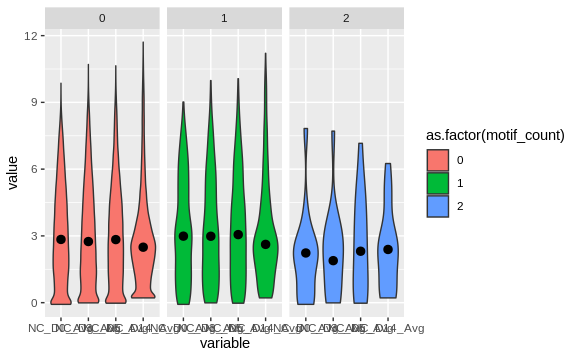

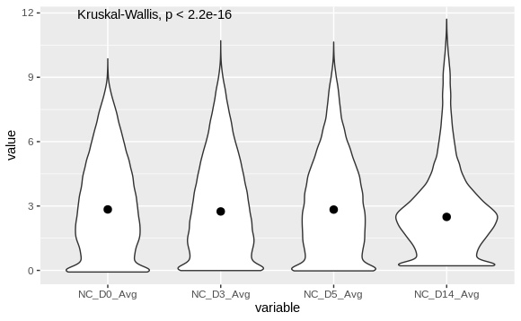

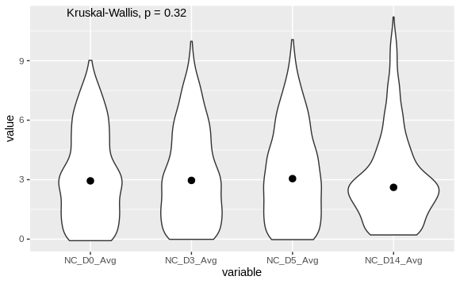

```r
ggplot(rld_df_melt, aes(x = variable, y = value)) + geom_violin(aes(fill = as.factor(motif_count))) + stat_summary(fun = "median") + facet_grid(. ~ motif_count)


rld_df_melt_nomotifs <- subset(rld_df_melt, rld_df_melt$motif_count == 0)

nomotifs_plot <- ggplot(rld_df_melt_nomotifs, aes(x = variable, y = value)) + geom_violin() + stat_summary(fun = "median") + stat_compare_means()
nomotifs_plot


rld_df_melt_onemotifs <- subset(rld_df_melt, rld_df_melt$motif_count >= 1)

onemotifs_plot <- ggplot(rld_df_melt_onemotifs, aes(x = variable, y = value)) + geom_violin() + stat_summary(fun = "median") + stat_compare_means()
onemotifs_plot
```

```
Removed 4 rows containing missing values (geom_segment).Removed 4 rows containing missing values (geom_segment).
```

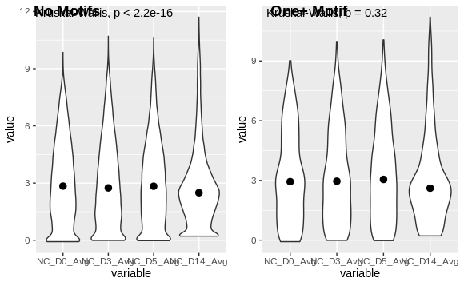

```r
cowplot::plot_grid(nomotifs_plot,onemotifs_plot,ncol = 2, labels = c("No Motifs", "One+ Motif"))
```

```r
# Let's see the Sox2 signal at Sox2 peaks with or without the motif at d0, d3, d5

cd /data/Austin/workdir/NC_Timecourse_Data/Human_ESC_iNC_CR/BW

computeMatrix reference-point -S  H1_Sox2_auto_ACAGTG_hg38_filt.BAM.bw Sox2_NC_day3_R2_gthg38_filt_nodups.BAM.bw Sox2_gt_NC_2hg38_filt_nodups.BAM.bw -R ~/local_git/NC_Timecourse/CR/Human_ESC_iNC/Exports/Sox2_peaks_with_dualmotif.bed ~/local_git/NC_Timecourse/CR/Human_ESC_iNC/Exports/Sox2_peaks_with_no_dualmotif.bed -b 1000 -a 1000 -bs 10 -o ~/local_git/NC_Timecourse/CR/Human_ESC_iNC/Exports/Sox2_CR_dual_vs_no_motif_2.mat.gz --missingDataAsZero --referencePoint center --numberOfProcessors 62

plotProfile -m ~/local_git/NC_Timecourse/CR/Human_ESC_iNC/Exports/Sox2_CR_dual_vs_no_motif.mat.gz -out ~/local_git/NC_Timecourse/CR/Human_ESC_iNC/Exports/Sox2_CR_dual_vs_no_motif.eps --plotType heatmap --dpi 600

gs -dSAFER -dEPSCrop -r300 -sDEVICE=pngalpha -o ~/local_git/NC_Timecourse/CR/Human_ESC_iNC/Exports/Sox2_CR_dual_vs_no_motif.png ~/local_git/NC_Timecourse/CR/Human_ESC_iNC/Exports/Sox2_CR_dual_vs_no_motif.eps

plotHeatmap -m ~/local_git/NC_Timecourse/CR/Human_ESC_iNC/Exports/Sox2_CR_dual_vs_no_motif.mat.gz -out ~/local_git/NC_Timecourse/CR/Human_ESC_iNC/Exports/Sox2_CR_dual_vs_no_motif_heatmap.eps --plotType lines --dpi 600

gs -dSAFER -dEPSCrop -r300 -sDEVICE=pngalpha -o  ~/local_git/NC_Timecourse/CR/Human_ESC_iNC/Exports/Sox2_CR_dual_vs_no_motif_heatmap.png ~/local_git/NC_Timecourse/CR/Human_ESC_iNC/Exports/Sox2_CR_dual_vs_no_motif_heatmap.eps
```

```r
# Let's see the ATAC signal at ESC or NC specific peaks with the dimer motif.

cd /data/Austin/workdir/NC_Timecourse_Data/Human_ESC_ATAC/BW

computeMatrix reference-point -S  ATAC_ES_D0_1_toGRCh38_sorted_nodups.bw ATAC_NC_D3_1_toGRCh38_sorted_nodups.bw ATAC_NC_D5_2_toGRCh38_sorted_nodups.bw -R ~/local_git/NC_Timecourse/CR/Human_ESC_iNC/Exports/ESC_Specific_motifs.bed ~/local_git/NC_Timecourse/CR/Human_ESC_iNC/Exports/NC_Specific_motifs.bed -b 1000 -a 1000 -bs 10 -o ~/local_git/NC_Timecourse/CR/Human_ESC_iNC/Exports/ESC_vs_NC_withmotif.mat.gz --missingDataAsZero --referencePoint center --numberOfProcessors 62

plotProfile -m ~/local_git/NC_Timecourse/CR/Human_ESC_iNC/Exports/ESC_vs_NC_withmotif.mat.gz -out ~/local_git/NC_Timecourse/CR/Human_ESC_iNC/Exports/ESC_vs_NC_withmotif_profile.eps --plotType heatmap --dpi 600

gs -dSAFER -dEPSCrop -r300 -sDEVICE=pngalpha -o ~/local_git/NC_Timecourse/CR/Human_ESC_iNC/Exports/ESC_vs_NC_withmotif_profile.png ~/local_git/NC_Timecourse/CR/Human_ESC_iNC/Exports/ESC_vs_NC_withmotif_profile.eps

plotHeatmap -m ~/local_git/NC_Timecourse/CR/Human_ESC_iNC/Exports/ESC_vs_NC_withmotif.mat.gz -out ~/local_git/NC_Timecourse/CR/Human_ESC_iNC/Exports/ESC_vs_NC_withmotif_heatmap.eps --plotType lines --dpi 600

gs -dSAFER -dEPSCrop -r300 -sDEVICE=pngalpha -o  ~/local_git/NC_Timecourse/CR/Human_ESC_iNC/Exports/ESC_vs_NC_withmotif_heatmap.png ~/local_git/NC_Timecourse/CR/Human_ESC_iNC/Exports/ESC_vs_NC_withmotif_heatmap.eps
```